# 03Matplotlib第三段

```python
%%HTML
<style type='text/css'>
    *{
        # background-color:#E3EDCD;
        # background-color:black;
        # color:white;

    }
    h1{
        color:#1976d2;
    }
    h2{
        color:#f57c00;
    }
    h3{
        color:#ba37ff;
    }
    h4{
        color:green;
    }
    table{
        border:1px solid black !important;
        border-collapse:collapse !important;
    }
    th{
        background-color:blueviolet !important;
        text-align:center;
        color:white;
    }
    th,td{
        border:0.1px solid black !important;
        transition:0.2s all liner;

    }
    td:hover{
        transform:scale(1.1);
        background-color:orange;
        color:blueviolet;
    }
    .raw{
        white-space:pre;
    }
    .atcenter{
        text-align:center !important;
    }
    .imp{
        color:red;
        font-weight:bolder;
    }
</style>
```

## 4.9 配置颜色条

图例通过离散的标签表示离散的图形元素。然而，对于图形中由彩色的 点、线、面构成的连续标签，用颜色条来表示的效果比较好。在 Matplotlib 里面，颜色条是一个独立的坐标轴，可以指明图形中颜色的 含义。由于本书是单色印刷，你可以在本书在线附录 （[https://github.com/jakevdp/PythonDataScienceHandbook）中查看这一节](https://github.com/jakevdp/PythonDataScienceHandbook%EF%BC%89%E4%B8%AD%E6%9F%A5%E7%9C%8B%E8%BF%99%E4%B8%80%E8%8A%82) 图形的彩色版本。首先还是导入需要使用的画图工具：

```python
import matplotlib.pyplot as plt
import numpy as np
```

和在前面看到的一样，通过 plt.colorbar 函数就可以创建最简单的颜 色条（如图 4-49 所示）：

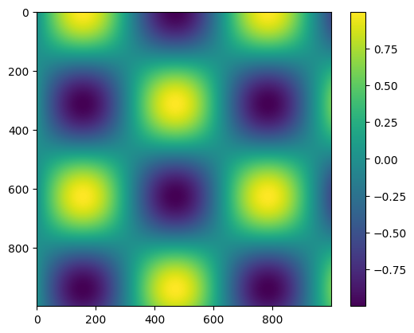

```python
x = np.linspace(0,10,1000)
I = np.sin(x)*np.cos(x[:,np.newaxis])
plt.imshow(I)
plt.colorbar()
```

图 4-49：一个简易的颜色条图例

### 4.9.1 配置颜色条

可以通过 cmap 参数为图形设置颜色条的配色方案（如图 4-50 所示）：

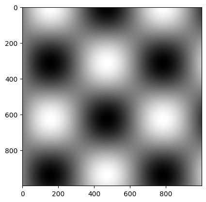

```python
plt.imshow(I,cmap='gray')
```

图 4-50：一个采用灰度配色方案的图形

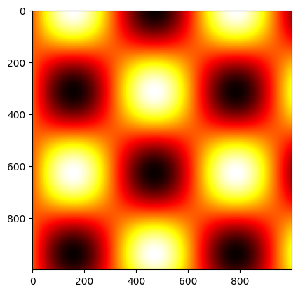

```python
plt.imshow(I,cmap='hot')
```

所有可用的配色方案都在 plt.cm 命名空间里面，在 IPython 里通过 Tab 键就可以查看所有的配置方案：

```
plt.cm.<TAB>
```

有了这么多能够作为备选的配色方案只是第一步，更重要的是如何确定 用哪种方案！最终的选择结果可能和你一开始想用的有很大不同

#### 01. 选择配色方案

关于可视化图形颜色选择的全部知识超出了本书的介绍范围，但如 果你想了解与此相关的入门知识，可以参考文章“Ten Simple Rules for Better Figures”（[http://bit.ly/2fDJn9J）。Matplotlib](http://bit.ly/2fDJn9J%EF%BC%89%E3%80%82Matplotlib) 的在线文档中 也有关于配色方案选择的有趣论述 （[http://matplotlib.org/1.4.1/users/colormaps.html）。](http://matplotlib.org/1.4.1/users/colormaps.html%EF%BC%89%E3%80%82)

一般情况下，你只需要重点关注三种不同的配色方案

#### 顺序配色方案

由一组连续的颜色构成的配色方案（例如 binary 或 viridis）。

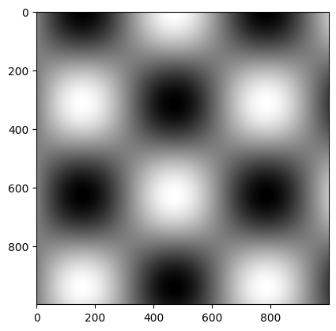

```python
plt.imshow(I,cmap='binary')
```

#### 互逆配色方案

通常由两种互补的颜色构成，表示正反两种含义（例如 RdBu 或 PuOr）。

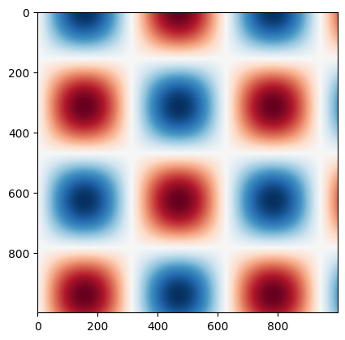

```python
plt.imshow(I,cmap='RdBu')
```

#### 定性配色方案

随机顺序的一组颜色（例如 rainbow 或 jet）。

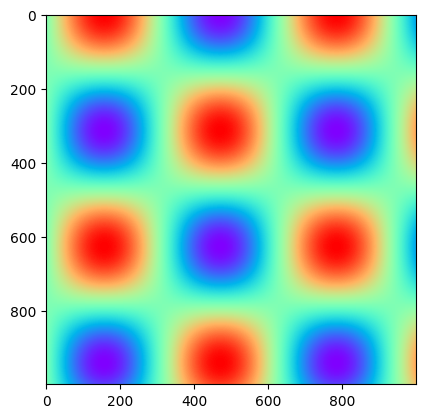

```python
plt.imshow(I,cmap='rainbow')
```

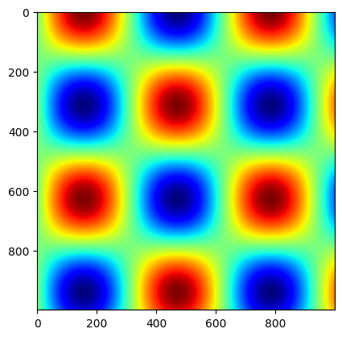

```python
plt.imshow(I,cmap='jet')
```

jet 是一种定性配色方案，曾是 Matplotlib 2.0 之前所有版本的默认 配色方案。把它作为默认配色方案实在不是个好主意，因为定性配 色方案在对定性数据进行可视化时的选择空间非常有限。随着图形 亮度的提高，经常会出现颜色无法区分的问题。  
可以通过把 jet 转换为黑白的灰度图看看具体的颜色（如图 4-51 所示）：

```python
from matplotlib.colors import LinearSegmentedColormap
def grayscale_cmap(cmap):
    """为配色方案显示灰度图"""
    cmap = plt.get_cmap(cmap)
    colors = cmap(np.arange(cmap.N))
    # 将RGBA色转换为不同亮度的灰度值
    # 参考链接http://alienryderflex.com/hsp.html
    RGB_weight = [0.299, 0.587, 0.114]
    luminance = np.sqrt(np.dot(colors[:, :3] ** 2, RGB_weight))
    colors[:, :3] = luminance[:, np.newaxis]
    return LinearSegmentedColormap.from_list(cmap.name + "_gray", colors, cmap.N)
def view_colormap(cmap):
    """用等价的灰度图表示配色方案"""
    cmap = plt.get_cmap(cmap)
    colors = cmap(np.arange(cmap.N))
    cmap = grayscale_cmap(cmap)
    grayscale = cmap(np.arange(cmap.N))
    fig, ax = plt.subplots(2, figsize=(6, 2),
    subplot_kw=dict(xticks=[], yticks=[]))
    ax[0].imshow([colors], extent=[0, 10, 0, 1])
    ax[1].imshow([grayscale], extent=[0, 10, 0, 1])
```

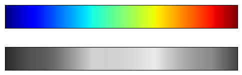

```python
view_colormap('jet')
```

图 4-51：jet 配色方案与非等差的渐变亮度

注意观察灰度图里比较亮的那部分条纹。这些亮度变化不均匀的条 纹在彩色图中对应某一段彩色区间，由于色彩太接近容易突显出数 据集中不重要的部分，导致眼睛无法识别重点。更好的配色方案是 viridis（已经成为 Matplotlib 2.0 的默认配色方案）。它采用了精 心设计的亮度渐变方式，这样不仅便于视觉观察，而且转换成灰度 图后也更清晰（如图 4-52 所示）：

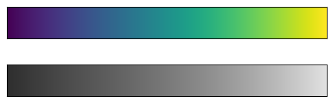

```python
view_colormap('viridis')
```

图 4-52：viridis 配色方案和渐变亮度 scale

如果你喜欢彩虹效果，可以用 cubehelix 配色方案来可视化连续 的数值（如图 4-53 所示）：

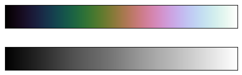

```python
view_colormap('cubehelix')
```

图 4-53：cubehelix 配色方案和渐变亮度

至于其他的场景，例如要用两种颜色表示正反两种含义时，可以使 用 RdBu 双色配色方案（红色 - 蓝色，Red-Blue 简称）。但正如图 4-54 所示，用红色、蓝色表示的正反两种信息在灰度图上看不出差 别！

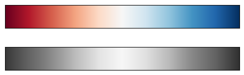

```python
view_colormap('RdBu')
```

图 4-54：RdBu 配色方案和渐变亮度

我们将在后面的章节中继续使用这些配色方案。 Matplotlib 里面有许多配色方案，在 IPython 里面用 Tab 键浏览 plt.cm 模块就可以看到所有内容。关于 Python 语言中配色的更多 基本原则，可以参考 Seaborn 程序库的工具和文档（详情请参 4.16 节）。

#### 02. 颜色条刻度的限制与扩展功能的设置

Matplotlib 提供了丰富的颜色条配置功能。由于可以将颜色条本身 仅看作是一个 plt.Axes 实例，因此前面所学的所有关于坐标轴和 刻度值的格式配置技巧都可以派上用场。颜色条有一些有趣的特 性。例如，我们可以缩短颜色取值的上下限，对于超出上下限的数 据，通过 extend 参数用三角箭头表示比上限大的数或者比下限小 的数。这种方法很简单，比如你想展示一张噪点图（如图 4-55 所 示）：

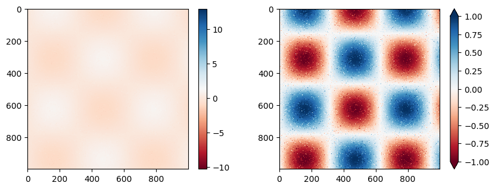

```python
# 为图形像素设置1%噪点
speckles = (np.random.random(I.shape) < 0.01)
I[speckles] = np.random.normal(0, 3, np.count_nonzero(speckles))
plt.figure(figsize=(10, 3.5))
plt.subplot(1, 2, 1) #生成多子图这个是其中一行两列的编号1(1,2,1)
plt.imshow(I, cmap='RdBu')
plt.colorbar()
plt.subplot(1, 2, 2) #生成多子图这个是其中一行两列的编号2(1,2,2)
plt.imshow(I, cmap='RdBu')
plt.colorbar(extend='both')
plt.clim(-1, 1);
```

图 4-55：设置颜色条扩展属性

左边那幅图是用默认的颜色条刻度限制实现的效果，噪点的范围完 全覆盖了我们感兴趣的数据。而右边的图形设置了颜色条的刻度上 下限，并在上下限之外增加了扩展功能，这样的数据可视化图形显 然更有效果。

#### 03. 离散型颜色条

虽然颜色条默认都是连续的，但有时你可能也需要表示离散数据。 最简单的做法就是使用 plt.cm.get_cmap() 函数，将适当的配色 方案的名称以及需要的区间数量传进去即可（如图 4-56 所示）：

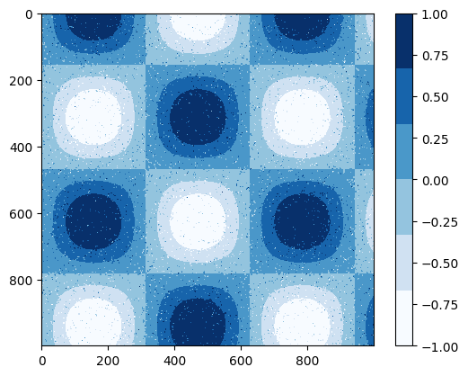

```python
plt.imshow(I,cmap=plt.get_cmap('Blues',6))
plt.colorbar()
plt.clim(-1,1) #限制色条的上下限
```

图 4-56：离散型颜色条

这种离散型颜色条和其他颜色条的用法相同。

### 4.9.2 案例：手写数字

让我们来看一些有趣的手写数字可视化图，这可能是一个比较实用的案 例。数据在 Scikit-Learn 里面，包含近 2000 份 8×8 的手写数字缩略图。 先下载数据，然后用 plt.imshow() 对一些图形进行可视化（如图 4-57 所示）：

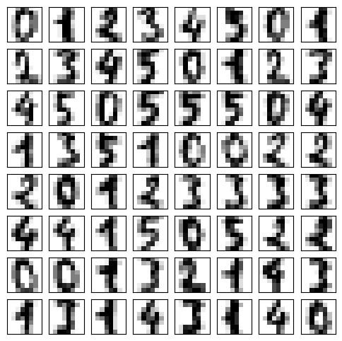

```python
# 加载0-5的图形，对其进行可视化
from sklearn.datasets import load_digits
digits = load_digits(n_class=6)
fig,ax = plt.subplots(ncols=8,nrows=8,figsize=(6,6))
for i,axi in enumerate(ax.flat):
    axi.imshow(digits.images[i],cmap='binary')
    axi.set(xticks=[],yticks=[])
```

图 4-57：手写数字样本

由于每个数字都由 64 像素的色相（hue）构成，因此可以将每个数字看 成是一个位于 64 维空间的点，即每个维度表示一个像素的亮度。但是 想通过可视化来描述如此高维度的空间是非常困难的。一种解决方案是 通过降维技术，在尽量保留数据内部重要关联性的同时降低数据的维 度，例如流形学习（manifold learning）。降维是无监督学习的重要内 容，5.1 节将详细介绍这部分知识。

暂且不提具体的降维细节，先来看看如何用流形学习将这些数据投影到 二维空间进行可视化（详情请参见 5.10 节）：

```
# 用IsoMap方法将数字投影到二维空间
from sklearn.manifold import Isomap
iso = Isomap(n_components=2)
projection = iso.fit_transform(digits.data)
```

我们将用离散型颜色条来显示结果，调整 ticks 与 clim 参数来改善颜 色条（如图 4-58 所示）：

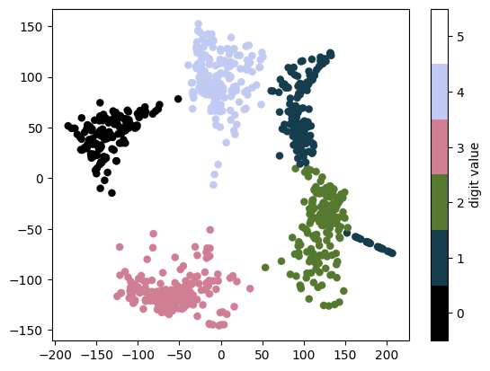

```python
from sklearn.manifold import Isomap
iso = Isomap(n_components=2)
projection = iso.fit_transform(digits.data)
plt.scatter(projection[:, 0], projection[:, 1], lw=0.1,
c=digits.target, cmap=plt.get_cmap('cubehelix', 6))
plt.colorbar(ticks=range(6), label='digit value')
plt.clim(-0.5, 5.5)
```

图 4-58：手写数字像素的流形学习结果

这个投影结果还向我们展示了一些数据集的有趣特性。例如，数字 5 与 数字 3 在投影中有大面积重叠，说明一些手写的 5 与 3 难以区分，因此 自动分类算法也更容易搞混它们。其他的数字，像数字 0 与数字 1，隔 得特别远，说明两者不太可能出现混淆。这个观察结果也符合我们的直 观感受，因为 5 和 3 看起来确实要比 0 和 1 更像。  
我们将在第 5 章深入学习流形学习和手写数字识别的相关内容。

## 4.10 多子图

有时候需要从多个角度对数据进行对比。Matplotlib 为此提出了子图 （subplot）的概念：在较大的图形中同时放置一组较小的坐标轴。这些 子图可能是画中画（inset）、网格图（grid of plots），或者是其他更复 杂的布局形式。在这一节中，我们将介绍四种用 Matplotlib 创建子图的 方法。首先，在 Notebook 中导入画图需要的程序库：

```
import matplotlib.pyplot as plt
    import numpy as np
```

### 4.10.1 plt.axes：手动创建子图

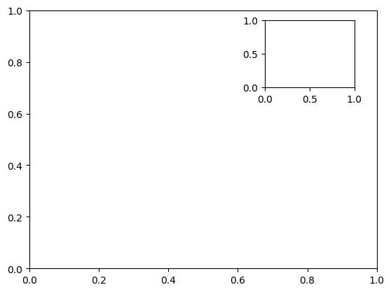

```python
ax1 = plt.axes()
ax2 = plt.axes([0.65,0.65,0.2,0.2])
```

图 4-59：图中图的坐标轴

面向对象画图接口中类似的命令有 fig.add_axes()。用这个命令创建 两个竖直排列的坐标轴（如图 4-60 所示）：

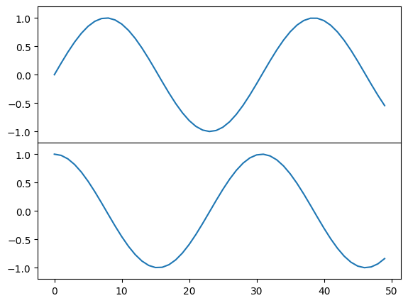

```python
fig = plt.figure()
ax1 = fig.add_axes([0.1, 0.5, 0.8, 0.4],
        xticklabels=[], ylim=(-1.2, 1.2))
ax2 = fig.add_axes([0.1, 0.1, 0.8, 0.4],
            ylim=(-1.2, 1.2))
x = np.linspace(0, 10)
ax1.plot(np.sin(x))
ax2.plot(np.cos(x));
```

图 4-60：竖直排列的坐标轴

现在就可以看到两个紧挨着的坐标轴（上面的坐标轴没有刻度）：上子 图（起点 y 坐标为 0.5 位置）与下子图的 x 轴刻度是对应的（起点 y 坐 标为 0.1，高度为 0.4）。

### 4.10.2 plt.subplot：简易网格子图

若干彼此对齐的行列子图是常见的可视化任务，Matplotlib 拥有一些可 以轻松创建它们的简便方法。最底层的方法是用 plt.subplot() 在一 个网格中创建一个子图。这个命令有三个整型参数——将要创建的网格 子图行数、列数和索引值，索引值从 1 开始，从左上角到右下角依次增 大（如图 4-61 所示）：

```python
plt.subplot?
```

[output not shown]

[output cut: 130 more lines]

[output not shown]

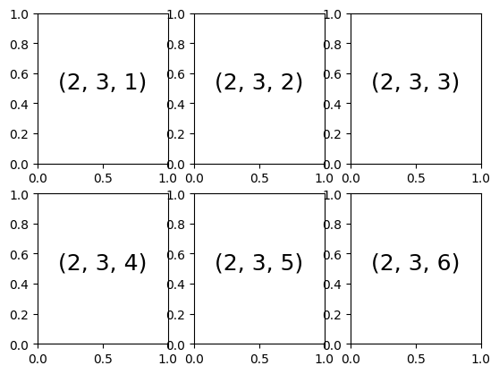

```python
for i in range(1,7):
    plt.subplot(2,3,i) #生成两行三列，其中i代表第几个图的编号
    plt.text(0.5,0.5,str((2,3,i)),fontsize=18,ha='center')
```

图 4-61：plt.subplot()

plt.subplots_adjust(left,right,bottom,top,wspace控制padding,hspace控制padding）) 命令可以调整子图之间的间隔。用面向对象接 口的命令 fig.add_subplot() 可以取得同样的效果（结果如图 4-62 所 示）：

```python
fig.subplots_adjust?
```

```
Signature:
fig.subplots_adjust(
    left=None,
    bottom=None,
    right=None,
    top=None,
    wspace=None,
    hspace=None,
)
Docstring:
Adjust the subplot layout parameters.

Unset parameters are left unmodified; initial values are given by
:rc:`figure.subplot.[name]`.

Parameters
----------
left : float, optional
    The position of the left edge of the subplots,
    as a fraction of the figure width.
right : float, optional
    The position of the right edge of the subplots,
    as a fraction of the figure width.
bottom : float, optional
    The position of the bottom edge of the subplots,
    as a fraction of the figure height.
top : float, optional
    The position of the top edge of the subplots,
    as a fraction of the figure height.
wspace : float, optional
    The width of the padding between subplots,
    as a fraction of the average Axes width.
hspace : float, optional
    The height of the padding between subplots,
    as a fraction of the average Axes height.
File:      d:\virtualenvs\ai\lib\site-packages\matplotlib\figure.py
Type:      method
```

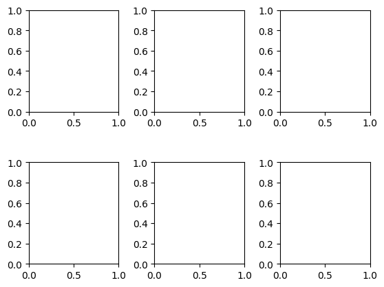

```python
fig,ax = plt.subplots(nrows=2,ncols=3,sharex=False,sharey=False)
fig.subplots_adjust(hspace=0.5, wspace=0.4)
```

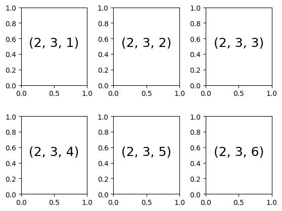

```python
fig = plt.figure()
fig.subplots_adjust(hspace=0.4, wspace=0.4)
for i in range(1, 7):
    ax = fig.add_subplot(2, 3, i)
    ax.text(0.5, 0.5, str((2, 3, i)),
        fontsize=18, ha='center')
```

图 4-62：带边距调整功能的 plt.subplot()

我们通过 plt.subplots_adjust 的 hspace 与 wspace 参数设置与图 形高度与宽度一致的子图间距，数值以子图的尺寸为单位（在本例中， 间距是子图宽度与高度的 40%）。

### 4.10.3 plt.subplots：用一行代码创建网格

当你打算创建一个大型网格子图时，就没办法使用前面那种亦步亦趋的 方法了，尤其是当你想隐藏内部子图的 x 轴与 y 轴标题时。出于这一需 求，plt.subplots() 实现了你想要的功能（需要注意此处 subplots 结尾多了个 s）。这个函数不是用来创建单个子图的，而是用一行代码 创建多个子图，并返回一个包含子图的 NumPy 数组。关键参数是行数 与列数，以及可选参数 sharex 与 sharey，通过它们可以设置不同子 图之间的关联关系。

我们将创建一个 2×3 网格子图，每行的 3 个子图使用相同的 y 轴坐标， 每列的 2 个子图使用相同的 x 轴坐标（如图 4-63 所示）：

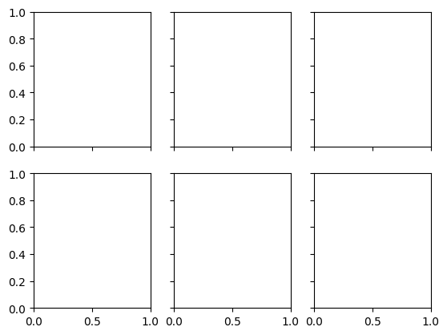

```python
fig,ax = plt.subplots(nrows=2,ncols=3,sharex='col',sharey='row')
```

图 4-63：plt.subplots() 方法共享 x 轴与 y 轴坐标

```python
# plt.text?
```

[output not shown]

[output cut: 70 more lines]

[output not shown]

设置 sharex 与 sharey 参数之后，我们就可以自动去掉网格内部子图 的标签，让图形看起来更整洁。坐标轴实例网格的返回结果是一个 NumPy 数组，这样就可以通过标准的数组取值方式轻松获取想要的坐 标轴了（如图 4-64 所示）：

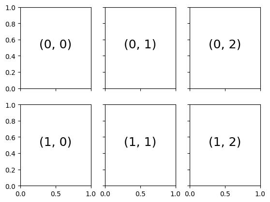

```python
# 坐标轴存放在一个NumPy数组中，按照[row, col]取值
for i in range(2):
    for j in range(3):
        ax[i, j].text(0.5, 0.5, str((i, j)), #其中的0.5,0.5表示居中
            fontsize=18, ha='center')
fig
```

图 4-64：确定网格中的子图

与 plt.subplot() 相比，plt.subplots() 与 Python 索引从 0 开始 的习惯保持一致。

### 4.10.4 plt.GridSpec：实现更复杂的排列方式

如果想实现不规则的多行多列子图网格，plt.GridSpec() 是最好的工 具。plt.GridSpec() 对象本身不能直接创建一个图形，它只是 plt.subplot() 命令可以识别的简易接口。例如，一个带行列间距的 2×3 网格的配置代码如下所示

```python
grid = plt.GridSpec(2,3,wspace=0.4,hspace=0.3) #生成两行三列的网格
```

可以通过类似 Python 切片的语法设置子图的位置和扩展尺寸（如图 4- 65 所示）：

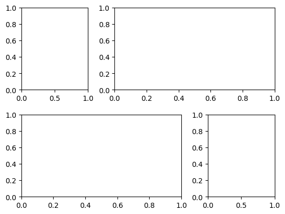

```python
plt.subplot(grid[0,0]) #第一个子图就占位00
plt.subplot(grid[0, 1:]) #第二个子图占位0行然后从1-2的宽度
plt.subplot(grid[1, :2]) # 第三个子图占位1行然后从0-1的宽度
plt.subplot(grid[1, 2]);# 第四个子图就占位1,2
```

图 4-65：用 plt.GridSpec 生成不规则子图

这种灵活的网格排列方式用途十分广泛，我经常会用它来创建如图 4-66 所示的多轴频次直方图（multi-axes histogram）（如图 4-66 所示）：

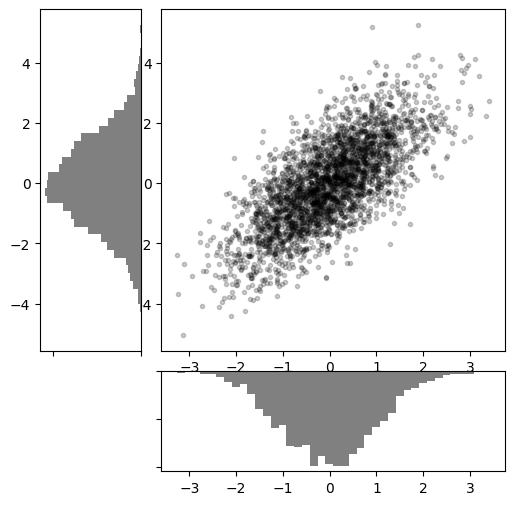

```python
# 创建一些正态分布数据
mean = [0, 0]
cov = [[1, 1], [1, 2]]
x, y = np.random.multivariate_normal(mean, cov, 3000).T
# 设置坐标轴和网格配置方式
fig = plt.figure(figsize=(6, 6))
grid = plt.GridSpec(4, 4, hspace=0.2, wspace=0.2)
main_ax = fig.add_subplot(grid[:-1, 1:])
y_hist = fig.add_subplot(grid[:-1, 0], xticklabels=[], sharey=main_ax)
x_hist = fig.add_subplot(grid[-1, 1:], yticklabels=[], sharex=main_ax)
# 主坐标轴画散点图
main_ax.plot(x, y, 'ok', markersize=3, alpha=0.2)
# 次坐标轴画频次直方图
x_hist.hist(x, 40, histtype='stepfilled',
orientation='vertical', color='gray')
x_hist.invert_yaxis()
y_hist.hist(y, 40, histtype='stepfilled',
orientation='horizontal', color='gray')
y_hist.invert_xaxis() #实现坐标轴转变方向的功能
```

图 4-66：用 plt.GridSpec 可视化多维分布数据

这种类型的分布图十分常见，Seaborn 程序包提供了专门的 API 来实现 它们，详情请参见 4.16 节。